# ANLY560: Lab 5 Assignment

Shivam Zala

# Problem 1

## Use the crude oil prices (use yahoo finance; ticker is “CL”; get prices from 1975-01-01)

```r
library(flipbookr)
library(tidyverse)
```

```r
library(ggplot2)
library(forecast)
library(astsa)
library(xts)
library(tseries)
library(fpp2)
library(fma)
library(lubridate)
library(tidyverse)
library(TSstudio)
library(quantmod)
library(tidyquant)
library(plotly)
library(ggplot2)
```

1. Plot the Crude Oil Prices (for the adjusted closing price) and comment your visual conclusions.

```r
CL<- getSymbols("CL",auto.assign = FALSE, from="2000-01-01",src="yahoo")
```

[output not shown]

```r
head(CL)
```

```
##            CL.Open  CL.High  CL.Low CL.Close CL.Volume CL.Adjusted
## 2000-01-03 32.0000 32.00000 31.0000 31.12500   2434800    19.44973
## 2000-01-04 30.6250 30.96875 30.2500 30.31250   2358400    18.94201
## 2000-01-05 30.3750 30.62500 28.8750 29.28125   3169400    18.29758
## 2000-01-06 29.0000 30.00000 28.9375 29.21875   5802200    18.25854
## 2000-01-07 29.5625 31.15625 29.0000 30.96875   5570200    19.35209
## 2000-01-10 31.7500 31.81250 30.8750 31.81250   3049600    19.87934
```

```r
tail(CL)
```

```
##            CL.Open CL.High CL.Low CL.Close CL.Volume CL.Adjusted
## 2022-03-28   74.84   75.42  74.84    75.39   3646200       75.39
## 2022-03-29   76.14   76.79  75.75    76.20   4651500       76.20
## 2022-03-30   75.55   76.38  75.39    76.36   4191400       76.36
## 2022-03-31   76.20   76.38  75.38    75.83   7711400       75.83
## 2022-04-01   75.87   76.44  75.11    76.42   6464700       76.42
## 2022-04-01   75.87   76.44  75.11    76.42   6464694       76.42
```

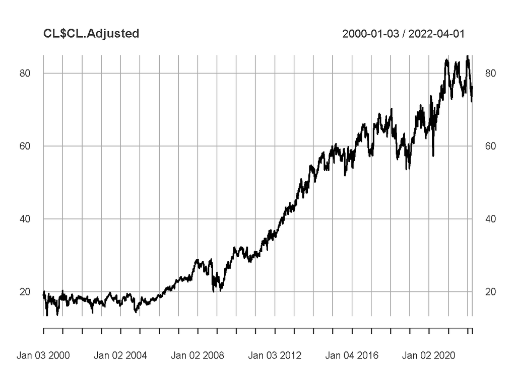

```r
plot(CL$CL.Adjusted)
```

```r
#The plot for Crude Oil prices from 2000-2022 has an almost 4 fold increase with the initital price increasing from 20 to nearly 80 with certain fluctuations.
```

```r
data <- read.csv("CL.csv", header = T)
head(data)
```

```
##         Date CL.Open  CL.High  CL.Low CL.Close CL.Volume CL.Adjusted
## 1 01-01-2000 32.0000 32.00000 31.0000 31.12500   2434800    19.44973
## 2 02-01-2000 30.6250 30.96875 30.2500 30.31250   2358400    18.94201
## 3 03-01-2000 30.3750 30.62500 28.8750 29.28125   3169400    18.29758
## 4 04-01-2000 29.0000 30.00000 28.9375 29.21875   5802200    18.25853
## 5 05-01-2000 29.5625 31.15625 29.0000 30.96875   5570200    19.35208
## 6 06-01-2000 31.7500 31.81250 30.8750 31.81250   3049600    19.87934
```

```r
data$Date <- as.Date(data$Date)
ts_data <- ts(data$CL.Adjusted, start=c(2010, 01),frequency=365)
```

2. Use the Augmented Dickey-Fuller Test to check the stationarity.

bb) Next, Use log transformation and plot the series. Comment. Do you see any difference with the original fluctuations?

```r
library(tseries)
adf.test(CL$CL.Adjusted)
```

```
##
##  Augmented Dickey-Fuller Test
##
## data:  CL$CL.Adjusted
## Dickey-Fuller = -3.2609, Lag order = 17, p-value = 0.07734
## alternative hypothesis: stationary
```

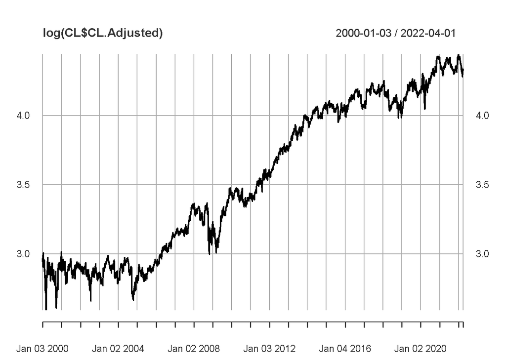

```r
#Since the value of Crude oil's adjusted price is just above 0.05,we fail to reject the null hypothesis.

#This means the time series is non-stationary. In other words, it has some time-dependent structure and does not have constant variance over time.

plot(log(CL$CL.Adjusted))
```

```r
#The plot of log transformed data follows the same trend but the fluctuations seem smoother
```

```r
adf.test(log(CL$CL.Adjusted))
```

```
##
##  Augmented Dickey-Fuller Test
##
## data:  log(CL$CL.Adjusted)
## Dickey-Fuller = -3.5606, Lag order = 17, p-value = 0.03641
## alternative hypothesis: stationary
```

```r
#The value of p is less than 0.05 which means that the log transformed data is stationary
```

4. Difference the transforemed time series data (part bb) until it is stationary/weakly stationary. Plot the differenced data and comment. Also, Use the ACf plot and the Augmented Dickey-Fuller Test to check the stationarity .

```r
ts.CL=ts(CL$CL.Adjusted, start=decimal_date(as.Date("2000-01-01")), frequency = 365.25)
adf.test(diff((ts.CL)))
```

```
##
##  Augmented Dickey-Fuller Test
##
## data:  diff((ts.CL))
## Dickey-Fuller = -18.777, Lag order = 17, p-value = 0.01
## alternative hypothesis: stationary
```

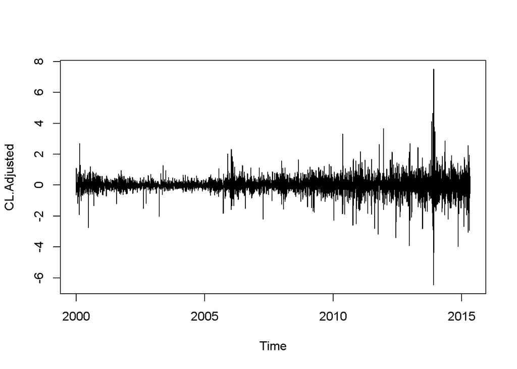

```r
plot(diff(ts.CL))
```

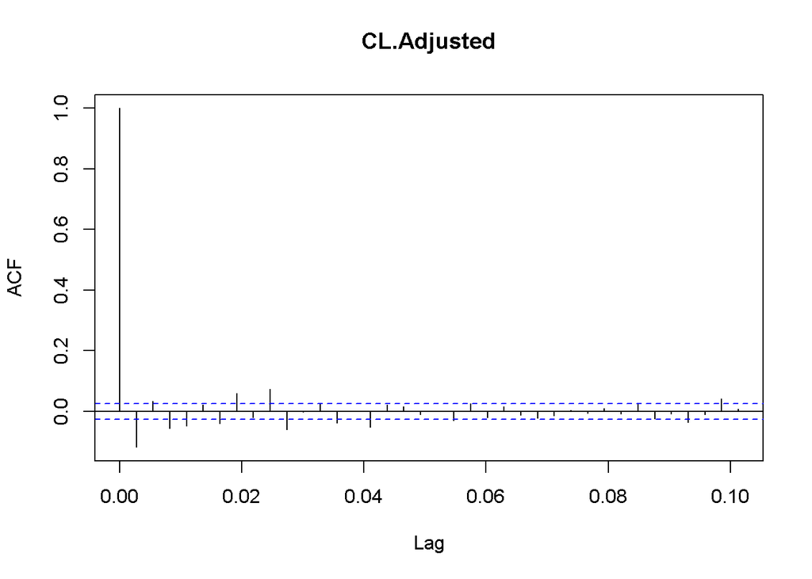

```r
acf(diff(ts.CL))
```

```r
#The plot is stationary as value of p is less than 0.05 and plot is also less volatile
```

5. Plot the ACF and PACF plot and decide the order (p,d,q) of your ARIMA(p,d,q) process.

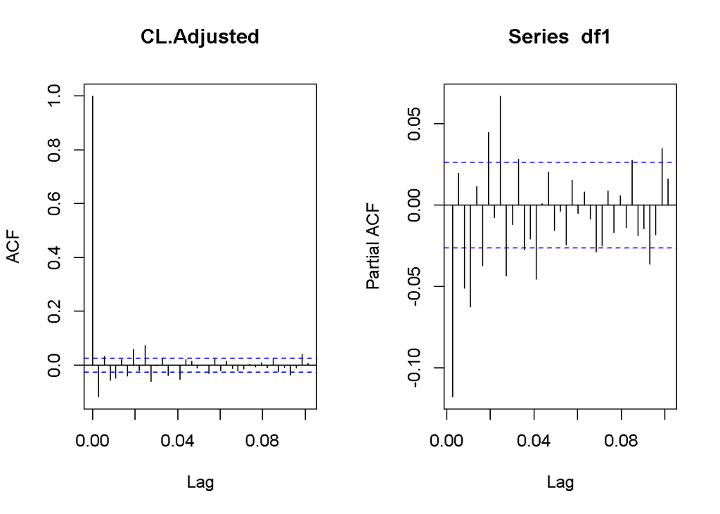

```r
#d=1
df1 <- diff(ts.CL)
par(mfrow=c(1,2))
acf(df1)  #q=2
pacf(df1) #p=2
```

6. Fit your choice of ARIMA(p,d,q) to the model using the code **sarima()**. If you have several choices for p,d,q you may select the model with lowest AIC, BIC or the model with the best model diagnostics.

```r
fit <- Arima(df1, order=c(2,1,2),include.drift = TRUE)
summary(fit)
```

```
## Series: df1
## ARIMA(2,1,2) with drift
##
## Coefficients:
##           ar1      ar2      ma1      ma2  drift
##       -0.4235  -0.0103  -0.6911  -0.3089      0
## s.e.   0.1599   0.0251   0.1590   0.1590      0
##
## sigma^2 = 0.2906:  log likelihood = -4486.28
## AIC=8984.57   AICc=8984.58   BIC=9024.35
##
## Training set error measures:
##                       ME      RMSE       MAE MPE MAPE      MASE          ACF1
## Training set 0.002817657 0.5388016 0.3370862 NaN  Inf 0.6896824 -0.0002044715
```

```r
fit <- Arima(df1, order=c(3,1,3),include.drift = TRUE)
summary(fit)
```

```
## Series: df1
## ARIMA(3,1,3) with drift
##
## Coefficients:
##           ar1      ar2      ar3      ma1     ma2      ma3  drift
##       -0.3911  -0.8094  -0.1180  -0.7226  0.5271  -0.8045      0
## s.e.   0.0803   0.0833   0.0164   0.0799  0.1158   0.0783      0
##
## sigma^2 = 0.2897:  log likelihood = -4476.35
## AIC=8968.7   AICc=8968.73   BIC=9021.74
##
## Training set error measures:
##                       ME      RMSE       MAE MPE MAPE      MASE         ACF1
## Training set 0.002826582 0.5378437 0.3372329 NaN  Inf 0.6899824 -0.001015488
```

**Write the equation of the model.** (Does this model looks familiar? is it a Random Walk? yes/no?)